# BayesianNetwork

Y.Nakahashi

2018/1/10

### 目的

*Bayesian Network*により変数間の関連性を図示し，かつその強さを定量的に示したい．

### 分析環境の準備

#### ライブラリの読み込み

```r
suppressMessages(library(BNSL))
suppressMessages(library(bnlearn))
```

#### サンプルデータの作成

[こちらの記事](http://d.hatena.ne.jp/isseing333/20100604)を参考にサンプルデータを作成した．一部の係数を修正したが，記事同様にHeightとSBPがBMIに刺さり，BMIがFBSに刺さる構造となっている．

| Height | BMI | SBP | FBS |
| --- | --- | --- | --- |
| 164.3952 | 26.99116 | 135.5871 | 115.66090 |
| 171.2929 | 24.95102 | 124.6092 | 92.10449 |
| 163.1315 | 24.68614 | 132.2408 | 107.02886 |
| 174.0077 | 21.22465 | 114.4416 | 103.99239 |
| 174.9785 | 27.99603 | 127.0136 | 115.25225 |
| 159.3218 | 11.53086 | 109.7400 | 30.36538 |

### 分析実行

#### 構造学習

Bayesian Networkはデータから変数間の関連性を推定する構造学習と，推定された構造を元にパラメータを推定するフィッティングの二段階で実施される．構造学習のアルゴリズムには*Grow-Shrink*を指定．Webだと*Hill-Climbing*が使われる事が多い様子だが，先ほど参照した記事によると*Grow-Shrink*はグラフ理論による裏付けがあるとのこと．

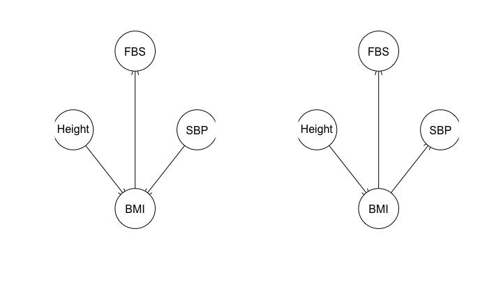

gsでは設定した通りの構造が推定されたが，hcではBMIとSBPの関係性が逆転している．

#### フィッティング

この構造を用いてパラメータを推定する．なおここで得られる係数は，個別にlmをかけたものと同じとなり，例えばBMIであればlm(BMI ~ Height + SBP)と等しい．

```r
(coef_01 <- coefficients(fit_01))
```

```
$Height
(Intercept)
    170.091

$BMI
(Intercept)      Height         SBP
     -123.0         0.5         0.5

$SBP
(Intercept)
   120.1408

$FBS
(Intercept)         BMI
 -20.240828    5.019595
```

```r
coef(lm(BMI ~ Height + SBP, Data2))
```

```
(Intercept)      Height         SBP
     -123.0         0.5         0.5
```

### 分析実行その２

#### 構造学習

次にサンプルデータの*gaussian.test*を用いてパラメータの推定を行う．元の構造はわからないが*gs*によって推定した形は以下のよう．

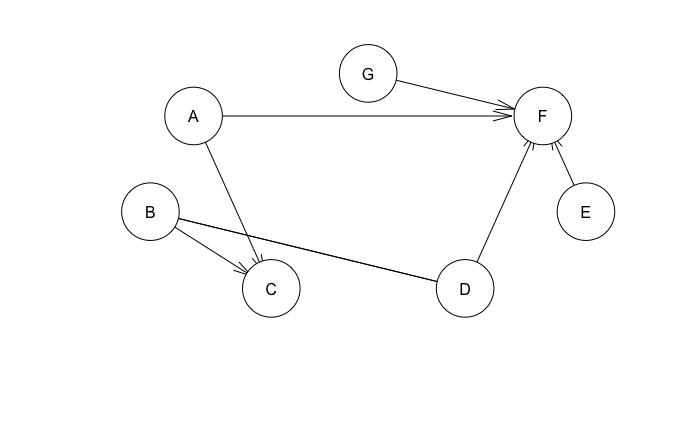

#### フィッティング

グラフの構造が悪く，フィッティングできない．

```r
fit_02 <- bn.fit(str_02, gaussian.test)
```

```
 bn.fit(str_02, gaussian.test) でエラー:
  the graph is only partially directed.
```

str_02の中身を確認すると，modelが[partially directed graph]となっていることがわかる．またarcsのundirected arcsが1になっている．

```r
str_02
```

```
  Bayesian network learned via Constraint-based methods

  model:
    [partially directed graph]
  nodes:                                 7
  arcs:                                  7
    undirected arcs:                     1
    directed arcs:                       6
  average markov blanket size:           4.00
  average neighbourhood size:            2.00
  average branching factor:              0.86

  learning algorithm:                    Grow-Shrink
  conditional independence test:         Pearson's Correlation
  alpha threshold:                       0.05
  tests used in the learning procedure:  144
  optimized:                             FALSE
```

再度str_02の構造を確認すると，ノードBD間のエッジが無向になっていることがわかる．

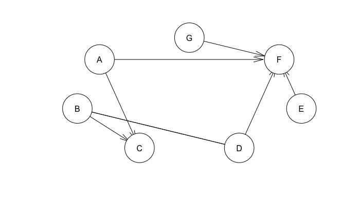

```r
plot(str_02)
```

そこでB -> Dのエッジを設定してみる．undirected arcsが0となり，modelがpartially directed graphではなくノード間の関連性を表したものとなっていることを確認する．

```r
(str_03 <- set.arc(str_02, "B", "D"))
```

```
  Bayesian network learned via Constraint-based methods

  model:
   [A][B][E][G][C|A:B][D|B][F|A:D:E:G]
  nodes:                                 7
  arcs:                                  7
    undirected arcs:                     0
    directed arcs:                       7
  average markov blanket size:           4.00
  average neighbourhood size:            2.00
  average branching factor:              1.00

  learning algorithm:                    Grow-Shrink
  conditional independence test:         Pearson's Correlation
  alpha threshold:                       0.05
  tests used in the learning procedure:  144
  optimized:                             FALSE
```

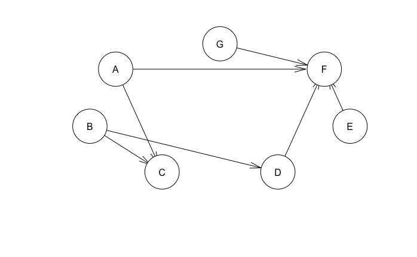

```r
plot(str_03)
```

この構造を用いて再度フィッティングしてみる．

```r
fit_03 <- bn.fit(str_03, gaussian.test)
(coef_03 <- coefficients(fit_03))
```

```
$A
(Intercept)
   1.007493

$B
(Intercept)
   2.039499

$C
(Intercept)           A           B
   2.001083    1.995901    1.999108

$D
(Intercept)           B
   5.995036    1.498395

$E
(Intercept)
   3.493906

$F
 (Intercept)            A            D            E            G
-0.006047321  1.994853041  1.005636909  1.002577002  1.494373265

$G
(Intercept)
   5.028076
```

今度は上手くいった！

### 分析実行その３

続いて直接効果と間接効果の分離を試みる．再度*gs*で構造を推定し，B -> Dのエッジと共にB -> Fのエッジも追加する．これでBはFに対して直接刺さるエッジとDを経由してFに刺さるエッジを持つことになる．

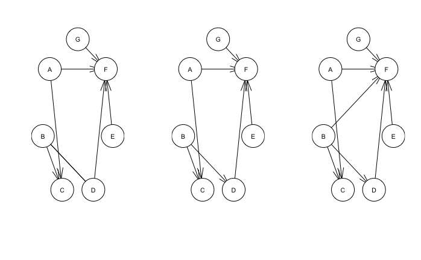

```r
coefficients(fit_04)
```

```
$A
(Intercept)
   1.007493

$B
(Intercept)
   2.039499

$C
(Intercept)           A           B
   2.001083    1.995901    1.999108

$D
(Intercept)           B
   5.995036    1.498395

$E
(Intercept)
   3.493906

$F
(Intercept)           A           B           D           E           G
 -0.4123157   1.9947919  -0.1025991   1.0737532   1.0023721   1.4943286

$G
(Intercept)
   5.028076
```

```r
coef(lm(F ~ A + B + D + E + G, gaussian.test))
```

```
(Intercept)           A           B           D           E           G
 -0.4123157   1.9947919  -0.1025991   1.0737532   1.0023721   1.4943286
```

Bの変動による寄与はほとんどDを経由してFに影響しているようで，BのFへの直接の効果はなさそう．

### 分析実行その４

#### 構造学習

今度は構造の推定に*BNSL*を試してみる．

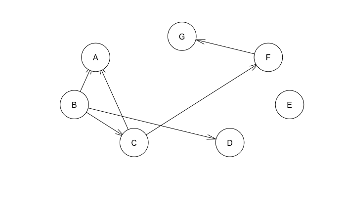

bnlearn::gsを用いた時と比べて構造がかなり異なる．比較してみる．

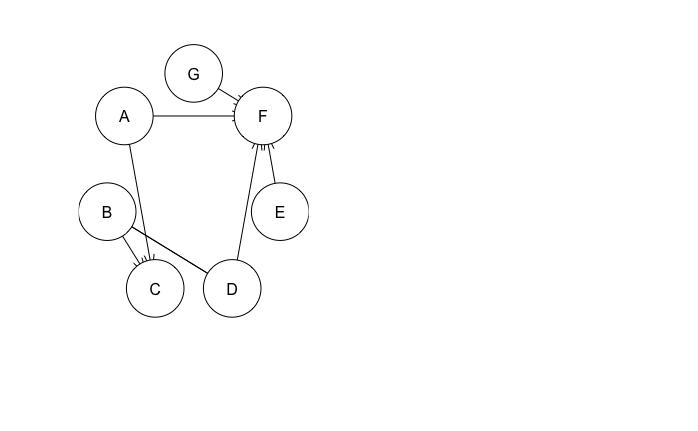

```r
par(mfrow = c(1, 2))
plot(str_02)
plot(str_05)
```

“A -> C”や“G -> F”など，方向性が逆転する関係が見られる．Eも独立してしまった．

#### フィッティング

この構造でフィッティングしてみる．フィッティング自体はbnlearn::bn.fitを用いる．

```r
fit_05 <- bn.fit(str_05, gaussian.test)
coefficients(fit_05)
```

```
$A
(Intercept)           B           C
 -0.8797297  -0.9414394   0.4706678

$B
(Intercept)
   2.039499

$C
(Intercept)           B
   4.047128    1.981855

$D
(Intercept)           B
   5.995036    1.498395

$E
(Intercept)
   3.493906

$F
(Intercept)           C
 15.8800425   0.7717126

$G
(Intercept)           F
  1.6423929   0.1530424
```

### 分析実行その５

さらに続いて，データを標準化した場合の結果も確認してみる．*scale*でデータを標準化する．

```r
my_gaussian <- as.data.frame(scale(gaussian.test))
str_06 <- bnsl(my_gaussian)
```

```
goal: 1111111, 25878.1, 25878.1, 0
```

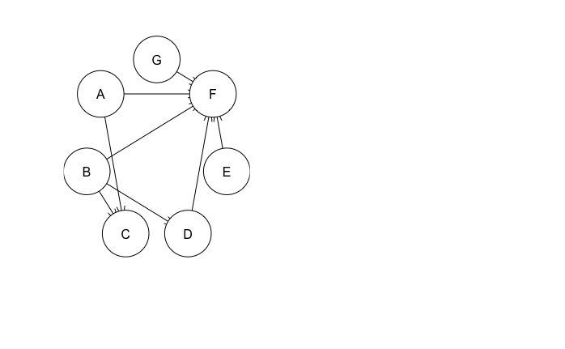

```r
par(mfrow = c(1, 2))
plot(str_04)
plot(str_06)
```

標準化すると構造が変わってしまう．

```r
fit_06 <- bn.fit(str_06, my_gaussian)
coefficients(fit_06)
```

```
$A
  (Intercept)             B             C
-4.475454e-16 -2.844392e+00  2.980174e+00

$B
  (Intercept)
-5.402467e-17

$C
  (Intercept)             B             D
 1.219489e-16  9.575318e-01 -1.188824e-02

$D
  (Intercept)             B
-8.063159e-17  9.973976e-01

$E
 (Intercept)
1.292542e-18

$F
  (Intercept)             C             E
-3.182043e-16  7.927020e-01  3.210430e-01

$G
  (Intercept)             C             F
 4.127384e-16 -1.015044e+00  1.282251e+00
```

### 分析実行その６

ライブラリ{MASS}に格納されているサンプルデータbirthwtを用いて推定してみる（ただしbnlearnではintegerは使えないのでnumericに変換し，変数も一部に限定する）．

#### 構造学習

構造学習のアルゴリズムには色々なものを指定してみる．

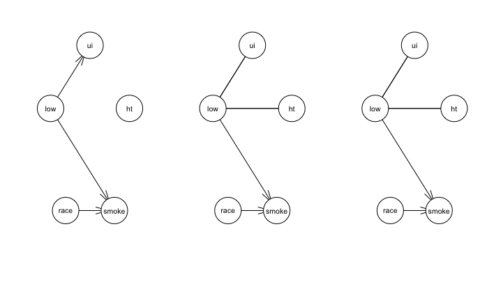

```r
vars <- c("low", "race", "smoke", "ht", "ui")
my_birthwt <- as.data.frame((do.call("cbind", lapply(birthwt[, vars],
                                                     as.numeric))))
str_07_01 <- hc(my_birthwt)
str_07_02 <- gs(my_birthwt)
str_07_03 <- iamb(my_birthwt)
str_07_04 <- fast.iamb(my_birthwt)
str_07_05 <- inter.iamb(my_birthwt)
str_07_06 <- tabu(my_birthwt)
str_07_07 <- mmhc(my_birthwt)
str_07_08 <- rsmax2(my_birthwt)
str_07_09 <- mmpc(my_birthwt)
str_07_10 <- si.hiton.pc(my_birthwt)
str_07_11 <- chow.liu(my_birthwt)
str_07_12 <- aracne(my_birthwt)
par(mfrow = c(1, 3))
plot(str_07_01)
plot(str_07_02)
plot(str_07_03)
par(mfrow = c(1, 3))
plot(str_07_04)

plot(str_07_05)
plot(str_07_06)
```

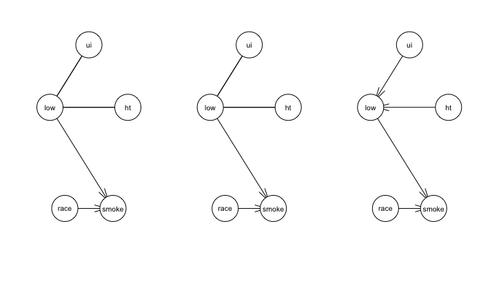

```r
par(mfrow = c(1, 3))
```

```r
plot(str_07_07)
plot(str_07_08)
```

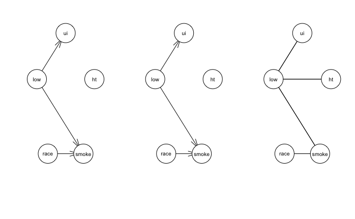

```r
plot(str_07_09)
par(mfrow = c(1, 3))
```

```r
plot(str_07_10)
plot(str_07_11)
```

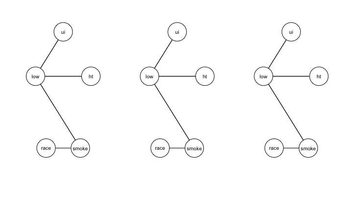

```r
plot(str_07_12)
```

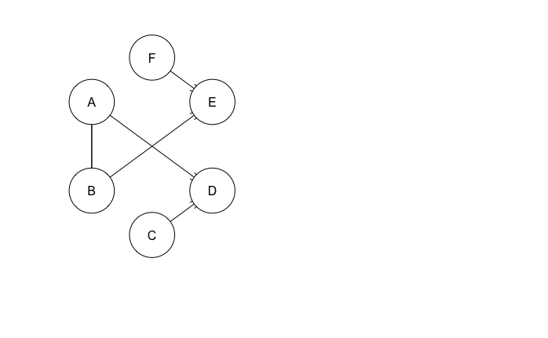

```r
str_07 <- gs(learning.test)
str_08 <- gs(learning.test, optimized = TRUE)
par(mfrow = c(1, 2))
plot(str_07)
plot(str_08)
```

```r
str_09 <- set.arc(str_07, "A", "B")
bn.fit(str_09, learning.test, method = "mle")
```

```
  Bayesian network parameters

  Parameters of node A (multinomial distribution)

Conditional probability table:
      a      b      c
0.3336 0.3340 0.3324

  Parameters of node B (multinomial distribution)

Conditional probability table:

   A
B            a          b          c
  a 0.85611511 0.44491018 0.11492178
  b 0.02517986 0.22095808 0.09446450
  c 0.11870504 0.33413174 0.79061372

  Parameters of node C (multinomial distribution)

Conditional probability table:
      a      b      c
0.7434 0.2048 0.0518

  Parameters of node D (multinomial distribution)

Conditional probability table:

, , C = a

   A
D            a          b          c
  a 0.80081301 0.09251810 0.10530547
  b 0.09024390 0.80209171 0.11173633
  c 0.10894309 0.10539019 0.78295820

, , C = b

   A
D            a          b          c
```

[output cut: 24 more lines]

```

, , F = b

   B
E            a          b          c
  a 0.40050804 0.31679389 0.23759542
  b 0.49026249 0.36641221 0.50667939
  c 0.10922947 0.31679389 0.25572519


  Parameters of node F (multinomial distribution)

Conditional probability table:
      a      b
0.5018 0.4982
```

```r
bn.fit(str_09, learning.test, method = "bayes")
```

```
  Bayesian network parameters

  Parameters of node A (multinomial distribution)

Conditional probability table:
         a         b         c
0.3335999 0.3339999 0.3324002

  Parameters of node B (multinomial distribution)

Conditional probability table:

   A
B            a          b          c
  a 0.85601066 0.44488791 0.11496558
  b 0.02524143 0.22098051 0.09451240
  c 0.11874792 0.33413158 0.79052202

  Parameters of node C (multinomial distribution)

Conditional probability table:
         a         b         c
0.7433180 0.2048257 0.0518563

  Parameters of node D (multinomial distribution)

Conditional probability table:

, , C = a

   A
D            a          b          c
  a 0.80077078 0.09253963 0.10532583
  b 0.09026586 0.80204982 0.11175613
  c 0.10896336 0.10541056 0.78291804

, , C = b

   A
D            a          b          c
```

[output cut: 24 more lines]

```

, , F = b

   B
E           a         b         c
  a 0.4004986 0.3168044 0.2376106
  b 0.4902403 0.3663912 0.5066518
  c 0.1092611 0.3168044 0.2557375


  Parameters of node F (multinomial distribution)

Conditional probability table:
         a         b
0.5017996 0.4982004
```